# Energy_Data.discription

JS Jeong

2018/ 1/ 13

##### id는 272개

##### id별로 2016-01-01부터 15분 간격으로 전력사용량 기록

##### 시작점은 모두 2016-01-01로 동일하지만, 종료시점은 대부분 2016-12-31이고 가장 마지막 기록은 2017-03-07이다.

##### data에서 기본적으로 발견되는 결측치는 768개이다.

```r
energy1 %>% distinct(id) %>%
  tail(5)
```

```
##             id
## 268 dfebc7ce65
## 269 419d06fa2c
## 270 40dec89827
## 271 cd0bc717c3
## 272 07eff25fb9
```

```r
table(is.na(energy1$usage))
```

```
##
##    FALSE     TRUE
## 10771756      768
```

```r
energy2016<- energy1 %>%
  mutate(year=year(date),
         month=month(date),
         day=day(date),
         wday=wday(date),
         hour=hour(date),
         minute=minute(date)) %>%
  dplyr::filter(year==2016)
```

```r
missing_value <- energy2016 %>%
  group_by(id) %>%
  summarise(real_obs=n())

missing_value$to_be_obs <- 35136
missing_value$diff <- missing_value$to_be_obs - missing_value$real_obs

missing_value<- missing_value %>%
  arrange(desc(diff))

min(missing_value$diff);max(missing_value$diff)
```

```
## [1] 10
```

```
## [1] 23537
```

```r
missing_value %>%
  head(5)
```

```
## # A tibble: 5 x 4
##           id real_obs to_be_obs  diff
##       <fctr>    <int>     <dbl> <dbl>
## 1 54dced63c8    11599     35136 23537
## 2 5146b56043    11791     35136 23345
## 3 91877062c7    13040     35136 22096
## 4 d35e39bc41    14623     35136 20513
## 5 b39ec9926b    14954     35136 20182
```

##### 10000개 이상 missing_value가 존재하는 14개의 id는 제외시켰다. 10000개를 기준으로 선택한 이유는 10000개가 105일로서 거의 한 분기에 해당하기 때문이다. 총 258개이다.

###### 코드 자동화 방법 생각하기!

```r
except_missing_id<- energy2016 %>%
  dplyr::filter(id!="54dced63c8" & id!="5146b56043" & id!="91877062c7" & id!="d35e39bc41" & id!="b39ec9926b" & id!="617735d397" & id!="d303903e33" & id!="49dd23568a" & id!="445bfdaecf" & id!="4c2931dab8" & id!="02b24c86ea" & id!="93ed07296d" & id!="2e61d57179" & id!="07eff25fb9")

except_missing_id %>%
  distinct(id) %>%
  tail(3)
```

```
##             id
## 256 419d06fa2c
## 257 40dec89827
## 258 cd0bc717c3
```

## NA 채우기

##### 각각의 id(258개)들의 관측치가 35136개가 되도록 관측되지 않은 날을 NA로 채웠다.

```r
unique_id <- unique(except_missing_id$id)
p <- list()
for (i in 1:length(unique_id)) {
  subset_id<- except_missing_id %>%
    dplyr::filter(id==unique_id[i]) %>%
    dplyr::select(-id)
  min <- min(subset_id$date)
  max <- max(subset_id$date)
  full_day<-expand.grid(date = seq(min, max,length.out = 35136))
  p[[i]] <- merge(x=subset_id,y=full_day, by ="date",all.y = T)
  p[[i]]$id<-unique_id[i]
}
```

##### list로 저장된 것을 data.frame으로 묶었다. 데이터 총 갯수는 (id 258개 X 하루측정치 96개 X 366일 = 9,065,088개)로 확인 된다. NA는 총 319,422개 이다

```r
final_energy<- rbindlist(p)

final_energy <- final_energy %>%
  select(id,date,usage)

table(is.na(final_energy$usage))
```

```
##
##   FALSE    TRUE
## 8745666  319422
```

## NA 보정

##### NA를 직전/직후 usage의 평균으로 대체하였다.

```r
#usage ts함수로 변환
timeseries.usage<- ts(final_energy$usage)
#NA를 직전 usage로 대체하는 식
input_before<- interpNA(timeseries.usage, method = c("before"))
#NA를 직후 usage로 대체하는 식
input_after<- interpNA(timeseries.usage, method = c("after"))
#직전 / 직후로 변환한 usage자료를 data.frame으로 합침
input_sum<- data.frame(input_before,input_after)
colnames(input_sum)<- c('before','after')

#NA를 직전/직후 usage의 평균으로 대체
adj_usage<-input_sum %>%
  mutate(bf_mean=(before+after)/2) %>%
  select(bf_mean)
```

```r
final_energy<-cbind(final_energy,adj_usage)

final_energy<-final_energy %>%
    mutate(year=year(date),
         month=month(date),
         day=day(date),
         wday=wday(date),
         hour=hour(date),
         minute=minute(date))

final_energy<-final_energy %>%
  dplyr::mutate(date = make_datetime(year,month,day,wday,hour))
```

## outlier 제거

##### 모든 id들의 일별 usage 평균을으라 그래프에서 보면, 3월에 눈에띄는 outlier가 존재한다. 또한 7&8월의 usage가 나머지 month와 뚜렷한 차이를 보인다.

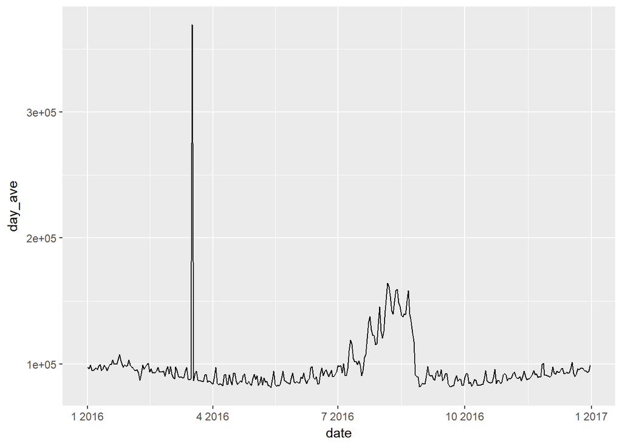

```r
daily<-final_energy %>%
  mutate(date = make_date(year,month,day)) %>%
  group_by(date) %>%
  summarise(day_ave= mean(bf_mean) )


ggplot(daily, aes(date, day_ave)) +
  geom_line()
```

##### 따라서, 7&8월과 나머지 month를 구분하여 outlier를 제거하였다.

##### Friedman’s Super Smoother방법을 이용하여 outlier를 제거했다

##### timeSeries::tsclean() 함수

```r
#7,8월 제외 month 추출
other_month<- final_energy %>%
  dplyr::filter(month!=7 & month!=8)

#outlier를 제거한 usage를 final usage로 저장
final_usage<-tsclean(other_month$bf_mean)

#final_usage를 기존 other_month data에 결합
other_month<-cbind(other_month,final_usage)
```

##### 7&8월을 제외한 month들의 day usage 평균치를 outlier 제거 전과 후를 비교하면 그래프와 같다.

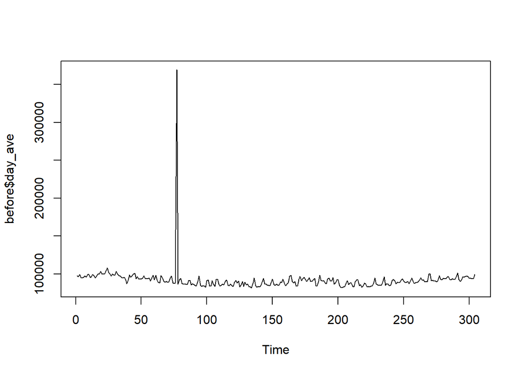

```r
before<-other_month %>%
  mutate(date = make_date(year,month,day)) %>%
  group_by(date) %>%
  summarise(day_ave= mean(bf_mean))

after<-other_month %>%
  mutate(date = make_date(year,month,day)) %>%
  group_by(date) %>%
  summarise(day_ave= mean(final_usage))

plot.ts(before$day_ave)
```

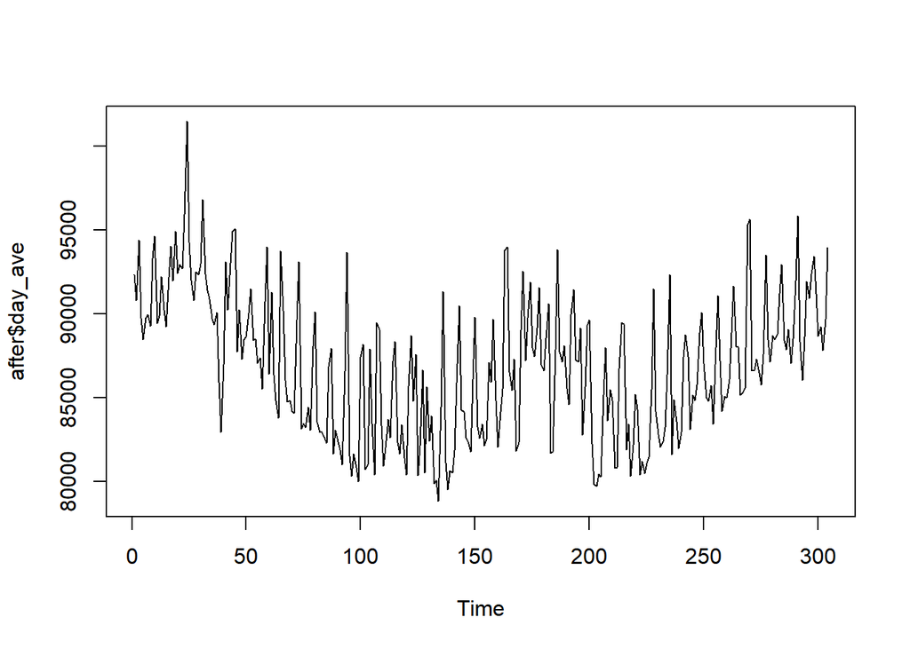

```r
plot.ts(after$day_ave)
```

##### 7&8월달도 동일하게 시행한 후 최종 data를 만들었다.

```r
#위의 other_month와 동일한 시행
summer_month<-final_energy %>%
  dplyr::filter(month == 7 | month == 8)
final_usage<-tsclean(summer_month$bf_mean)
summer_month<-cbind(summer_month,final_usage)
```

##### NA와 outlier가 제거된 최종 data

```r
#other_month와 summer_month를 행결합
final_energy <- rbind(summer_month, other_month)

#id,date로 정렬
final_energy<- final_energy %>%
  select(id,date,final_usage) %>%
  arrange(id,date,final_usage) %>%
  mutate(year=year(date),
         month=month(date),
         day=day(date),
         wday=wday(date),
         hour=hour(date),
         minute=minute(date))
```